# OLS Regression

Week 5

Published

May 1, 2025

# Before we start

- Questions regarding Lab Assignment or the class?

[Download script](https://artur-baranov.github.io/nu-ps312-ds/scripts/ps312-d_05.qmd)

[Download data](https://artur-baranov.github.io/nu-ps312-ds/data/appelloyle_jprdata.dta)

# Agenda

- Replicating a study
- Running the regression
- Thinking about controls
- Starting diagnostics

# Set up

Today we are working with data from a published academic paper.[^1] Let’s replicate their study and think about the underlying causal relation.

**Qustion**

Here is the summary of the paper.

Appel and Loyle argue that post-conflict justice institutions act as credible signals of future stability, reducing investor uncertainty and thereby increasing foreign direct investment (FDI) in post-conflict states. They show empirically that post-conflict countries implementing restorative justice mechanisms receive significantly more FDI compared to those that do not, even after accounting for economic, political, and conflict-related factors.

Extract the following information:

- **Dependent variable (outcome)**:
- **Independent variable (explanatory variable)**:
- **Mechanism (why IV has influence on DV)**:
- **Control variables (potential confounders)**:

First, load the library

```r
library(dagitty)
```

Let’s fill in the directed acyclic graph (DAG) below.

```r
dag_appel_loyle = dagitty('dag {
                          IV -> DV
                          control -> IV
                          control -> DV
                          ... -> ...
                          }')
plot(dag_appel_loyle)
```

# Simple Linear Regression

Let’s load the data first. We need `foreign` library to load Stata `.dta` files.

```r
library(foreign)
appel_loyle_raw = read.dta("data/appelloyle_jprdata.dta")
```

Now, let’s load the `tidyverse` library for data wrangling, and start exploring the dataset.

```r
library(tidyverse)

colnames(appel_loyle_raw)
```

```
 [1] "testnewid_lag"       "ccode"               "id"
 [4] "damage"              "victory_lag"         "peace_agreement_lag"
 [7] "issue_territory_lag" "cw_duration_lag"     "fv8"
[10] "fv10"                "fv11"                "fv27"
[13] "fv34"                "v2diff"              "v3Mdiff"
[16] "coldwar"             "xratf"               "labor"
[19] "physint"             "worker"              "polity2"
[22] "v60mean"             "v63mean"             "v64mean"
[25] "truthvictim"
```

Doesn’t seem straightforward, right? To get the sense of what’s going on you can go to the original replication data folder of the study ([here](https://www.prio.org/journals/jpr/replicationdata)). But, to simplify the task, this script will guide you.

Our dependent variable is `v3Mdiff` and independent is `truthvictim`. Let’s rename that for the sake of clarity, to received foreign direct investments (fdi) and post-conflict justice (pcj) respectively.

```r
appel_loyle = appel_loyle_raw %>%
  mutate(fdi = v3Mdiff,
         pcj = truthvictim)
```

Conceptually, post-conflict justice is operationalized as presence of truth commissions and reparations programs after the conflict.

First, explore the foreign direct investment. What do you notice?

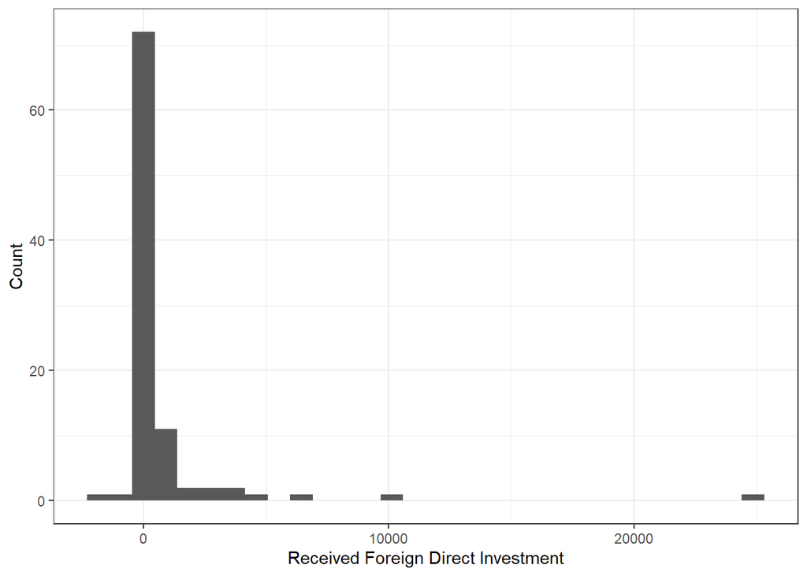

```r
ggplot(appel_loyle) +
  geom_histogram(aes(x = fdi)) +
  theme_bw() +
  labs(x = "Received Foreign Direct Investment",
       y = "Count")
```

Now, let’s see the distribution of the independent variable. How to fix the graph? When the graph is fixed, add the following line of code `scale_x_discrete(labels = c("Absent", "Present"))` to the graph.

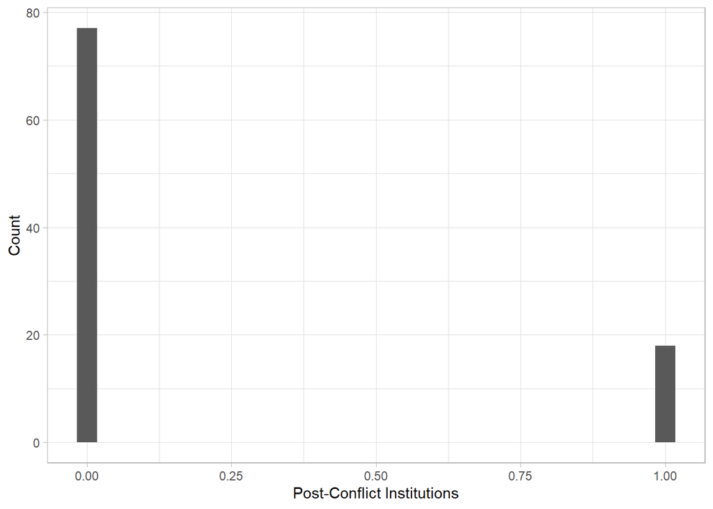

```r
ggplot(appel_loyle) +
  geom_histogram(aes(x = pcj)) +
  theme_light() +
  labs(x = "Post-Conflict Institutions",
       y = "Count")
```

Now, compare the distributions.

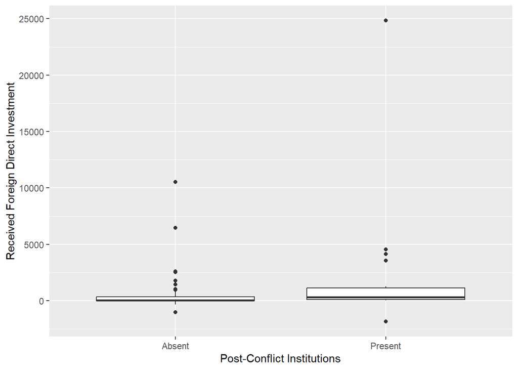

```r
ggplot(appel_loyle) +
  geom_boxplot(aes(x = as.factor(pcj), y = fdi)) +
  labs(x = "Post-Conflict Institutions",
       y = "Received Foreign Direct Investment") +
  scale_x_discrete(labels = c("Absent", "Present"))
```

Finally, let’s set up a simple linear regression. What does it mean?

```r
slr_model = lm(fdi ~ pcj, appel_loyle)
summary(slr_model)
```

```
Call:
lm(formula = fdi ~ pcj, data = appel_loyle)

Residuals:
    Min      1Q  Median      3Q     Max
-4047.4  -459.1  -418.7  -136.9 22648.3

Coefficients:
            Estimate Std. Error t value Pr(>|t|)
(Intercept)    425.0      323.9   1.312   0.1927
pcj           1763.5      744.0   2.370   0.0198 *
---
Signif. codes:  0 '***' 0.001 '**' 0.01 '*' 0.05 '.' 0.1 ' ' 1

Residual standard error: 2842 on 93 degrees of freedom
Multiple R-squared:  0.05696,   Adjusted R-squared:  0.04682
F-statistic: 5.618 on 1 and 93 DF,  p-value: 0.01985
```

# Multiple Linear Regression

## Economic Controls

Now, let’s think through control that authors use. First, focus on several economic control variables:

- Economic development (`fv8`) measured as GDP per capita
- Economic size (`fv10`) measured as GDP
- Female Life expectancy (`v64mean`)

Thus, this is how the authors model the real world. Does it raise any problems?

```
Plot coordinates for graph not supplied! Generating coordinates, see ?coordinates for how to set your own.
```

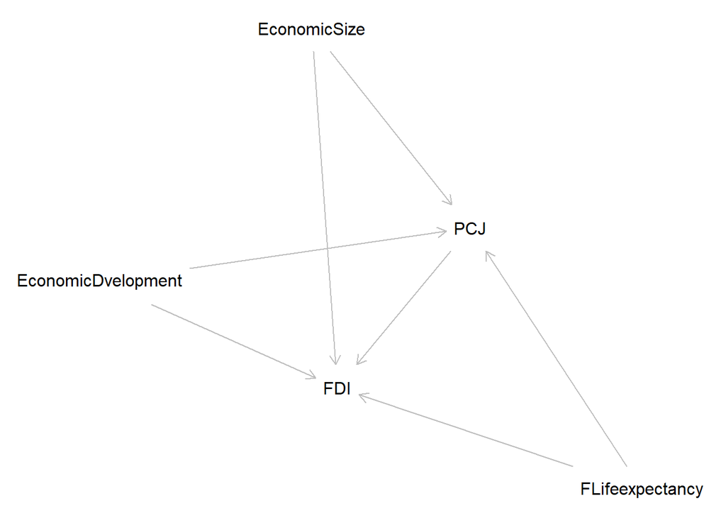

```r
econ_appel_loyle = dagitty('dag {
                          PCJ -> FDI
                          EconomicDvelopment -> PCJ
                          EconomicDvelopment -> FDI
                          EconomicSize -> FDI
                          EconomicSize -> PCJ
                          FLifeexpectancy -> FDI
                          FLifeexpectancy -> PCJ
                          }')
plot(econ_appel_loyle)
```

Again, let’s rename the variables for the sake of clarity

```r
appel_loyle = appel_loyle %>%
  rename(econ_development = fv8,
         econ_size = fv10,
         flife_exp = v64mean)
```

Now, let’s set up the multiple linear model! Do the results hold when we add controls?

```r
econ_model = lm(fdi ~ pcj + econ_development + econ_size + flife_exp, appel_loyle)
summary(econ_model)
```

```
Call:
lm(formula = fdi ~ pcj + econ_development + econ_size + flife_exp,
    data = appel_loyle)

Residuals:
    Min      1Q  Median      3Q     Max
-7348.9  -579.7   151.2   304.2 16072.0

Coefficients:
                   Estimate Std. Error t value Pr(>|t|)
(Intercept)      -7.637e+02  1.711e+03  -0.446   0.6563
pcj               1.544e+03  6.440e+02   2.397   0.0186 *
econ_development  2.753e-03  1.295e-01   0.021   0.9831
econ_size         7.561e-09  1.533e-09   4.933 3.68e-06 ***
flife_exp         9.793e+00  3.118e+01   0.314   0.7542
---
Signif. codes:  0 '***' 0.001 '**' 0.01 '*' 0.05 '.' 0.1 ' ' 1

Residual standard error: 2438 on 90 degrees of freedom
Multiple R-squared:  0.3283,    Adjusted R-squared:  0.2985
F-statistic:    11 on 4 and 90 DF,  p-value: 2.63e-07
```

## Political Controls

Now, let’s add political institutions.

- Domestic political constraints (`fv27`)
- Political regime (`polity2`)

**Coding Task**

First, add them to the DAG

```r
dagitty('dag {
              PCJ -> FDI
              EconomicDvelopment -> PCJ
              EconomicDvelopment -> FDI
              EconomicSize -> FDI
              EconomicSize -> PCJ
              FLifeexpectancy -> FDI
              FLifeexpectancy -> PCJ
              ...
              ...
                          }') %>%
plot()
```

Now, rename the variables, `polity2` to `regime` and `fv27` to `constraints`.

```r
appel_loyle = appel_loyle ...
  ...(regime = ...,
      ... = fv27)
```

Extend the previous model by adding political institutions. Present `summary()`. Is the main independent variable statistically significant?

```r
pol_model = lm(..., appel_loyle)
...
```

**Additional task**

Install and load library `texreg`, then run the `screenreg()` function on your model. In your free time feel free to explore `htmlreg()` for HTML and `texreg()` for PDF

# Model Diagnostics

Let’s take their full model, and run a quick diagnostic. The code below uses non-amended dataset, thus the names of the variables are not changed. Feel free to play around this after the section.

Most importantly, the PCJ is statistically significant.

```r
full_model = lm(v3Mdiff ~ truthvictim + fv8 + fv10 + fv11 + fv34 + fv27 + victory_lag + cw_duration_lag + damage + peace_agreement_lag + coldwar + polity2 + xratf + labor + v64mean, appel_loyle_raw)

summary(full_model)
```

```
Call:
lm(formula = v3Mdiff ~ truthvictim + fv8 + fv10 + fv11 + fv34 +
    fv27 + victory_lag + cw_duration_lag + damage + peace_agreement_lag +
    coldwar + polity2 + xratf + labor + v64mean, data = appel_loyle_raw)

Residuals:
    Min      1Q  Median      3Q     Max
-5308.4  -715.8   188.0   670.0 11747.4

Coefficients:
                      Estimate Std. Error t value Pr(>|t|)
(Intercept)         -1.278e+03  2.852e+03  -0.448  0.65525
truthvictim          1.960e+03  7.030e+02   2.788  0.00663 **
fv8                 -1.110e-01  1.329e-01  -0.835  0.40625
fv10                 1.095e-08  1.738e-09   6.301 1.56e-08 ***
fv11                 3.740e+01  2.324e+01   1.609  0.11152
fv34                 1.988e+02  2.016e+02   0.986  0.32701
fv27                 2.558e+03  1.460e+03   1.753  0.08357 .
victory_lag         -3.397e+01  6.507e+02  -0.052  0.95850
cw_duration_lag      8.111e-01  3.554e+01   0.023  0.98185
damage               2.838e+01  1.024e+01   2.771  0.00697 **
peace_agreement_lag -1.215e+03  7.938e+02  -1.531  0.12983
coldwar              8.153e+01  6.541e+02   0.125  0.90112
polity2             -9.017e+01  5.631e+01  -1.601  0.11330
xratf               -4.252e+01  1.389e+01  -3.061  0.00301 **
labor                9.844e+00  2.553e+01   0.386  0.70083
v64mean              3.475e+00  3.299e+01   0.105  0.91638
---
Signif. codes:  0 '***' 0.001 '**' 0.01 '*' 0.05 '.' 0.1 ' ' 1

Residual standard error: 2213 on 79 degrees of freedom
Multiple R-squared:  0.5141,    Adjusted R-squared:  0.4219
F-statistic: 5.573 on 15 and 79 DF,  p-value: 1.472e-07
```

Let’s load a `ggfortify` package for the diagnostics

```r
library(ggfortify)
```

We’ll get back to diagnostics in the upcoming weeks: but as a beginning, and most importantly, these patterns highlight possible problems with the model. Quite likely there are some outliers that might drive the result. If you can wait to get into a detail in these plots, feel free to use this [tutorial](https://library.virginia.edu/data/articles/diagnostic-plots).

- In your free time, try applying a log transformation to the dependent variable in the `full_model` and compare the diagnostic plots

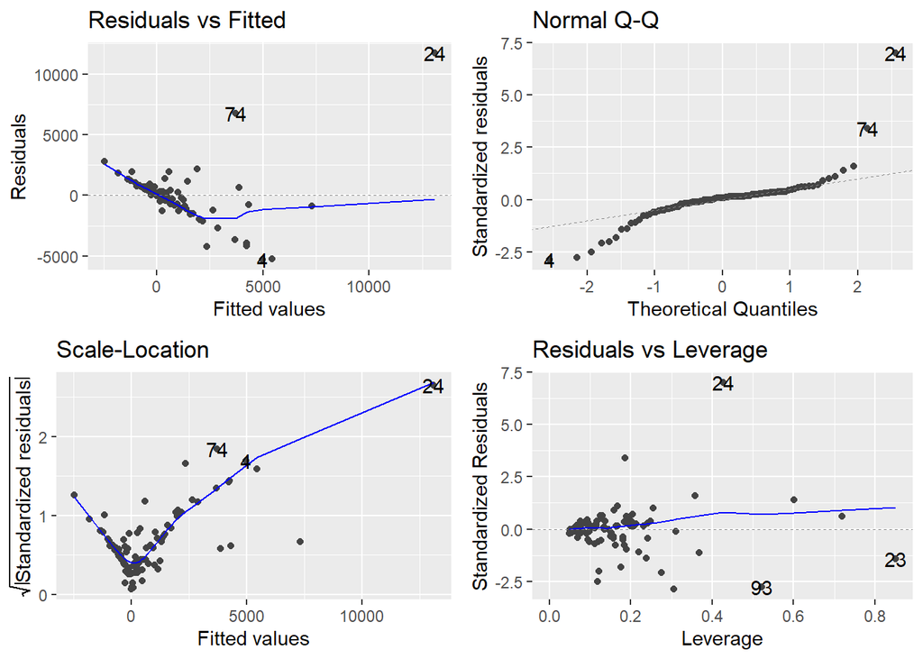

```r
autoplot(full_model)
```

# Some Tips

- When thinking about the statistical relationship, pay attention to the mechanism and causal pathway: how and why IV influences DV?
- Visualize the distributions! Highlight potential problems in the preliminary stage of data analysis

# Check List

I know how to explore variables, and plot their relationships

I am not afraid of multiple linear regression, and can easily interpret the coefficients and statistical significance

I am able to link my theoretical framework to empirically operationalized variables

I am gradually developing intuition behind model diagnostics

## Footnotes

[^1]: Appel, B.J. and Loyle, C.E., 2012. The economic benefits of justice: Post-conflict justice and foreign direct investment. *Journal of Peace Research*, 49(5), pp.685-699.